# Basic Tools For Forecasting

# Any outliers? (cont’d)

- For example: Consumer Prices (Consprix)

```r
cbind(German[,1], scale(German$Consprix))
```

```
##             Institutions scale(German$Consprix)
## 1             Bundesbank             -1.4626070
## 2            Commerzbank              0.0222732
## 3                   Deka              0.0222732
## 4          Deutsche Bank             -0.7201669
## 5                    DIW              3.3632536
## 6                DZ Bank              0.7647133
## 7                   Feri              0.3934932
## 8  Gemeinschaftsdiagnose              0.7647133
## 9                 Helaba              0.3934932
## 10                  HSBC              0.3934932
## 11                  HWWI              0.0222732
## 12                   Ifo             -1.0913869
## 13                   IfW              0.3934932
## 14                   IKB              0.0222732
## 15                   IMK             -0.7201669
## 16                   ING              0.3934932
## 17                    IW             -0.5345569
## 18                   IWH              0.3934932
## 19        Kiel Economics             -1.0913869
## 20     Landesbank Berlin             -1.0913869
## 21           MM Wartburg             -1.4626070
## 22              Postbank              0.3934932
## 23                   RWI             -0.7201669
## 24                   UBS              0.7647133
## 25      Wirtschaftsweise              0.3934932
```

# Any outliers? (cont’d)

```r
cbind(German[,1], round(scale(German[,-1]),3))
```

```
##             Institutions    GDP Privcons   GFCF Exports Imports Govsurp
## 1             Bundesbank -1.134    0.437 -0.840  -1.520  -0.713  -1.848
## 2            Commerzbank -0.732    1.429 -0.618  -0.573   0.421  -0.835
## 3                   Deka  0.072    0.767 -1.062  -0.046  -0.404  -0.024
## 4          Deutsche Bank -1.536   -0.886  0.493  -0.152   0.524  -0.835
## 5                    DIW  0.877    0.767  0.271   0.901   0.936   1.191
## 6                DZ Bank -1.134    0.106 -0.618  -0.362   0.111  -1.645
## 7                   Feri  2.083    1.098  1.382   0.796   0.421  -0.024
## 8  Gemeinschaftsdiagnose  1.279    0.767  1.382   0.480   0.936   0.381
## 9                 Helaba  1.681    1.098  2.160   2.269   1.349   1.191
## 10                  HSBC -0.330    0.437 -0.173  -0.467   0.421  -0.430
## 11                  HWWI -0.732    0.437  0.049   0.164   0.730   0.786
## 12                   Ifo  0.072   -0.556  0.049  -0.362  -0.404   0.786
## 13                   IfW -1.536   -0.886 -0.062  -0.467   0.214  -0.835
## 14                   IKB  0.474    0.106 -1.395   1.006   0.318   0.786
```

[output cut: 37 more lines]

# How to summarize the data of each variable in a concise way?

- What statistics are we going to present?
- For example: Consumer Prices (Consprix)

```r
summary(German$Consprix)
```

```
##    Min. 1st Qu.  Median    Mean 3rd Qu.    Max.
##   1.500   1.700   1.900   1.894   2.000   2.800
```

```r
sd(German$Consprix)
```

```
## [1] 0.269382
```

# How to summarize the data of each variable in a concise way? (cont’d)

```r
summary(German[,-1])
```

```
##       GDP           Privcons          GFCF           Exports
##  Min.   :0.300   Min.   :0.200   Min.   :-1.100   Min.   :0.600
##  1st Qu.:0.500   1st Qu.:0.700   1st Qu.: 0.100   1st Qu.:2.900
##  Median :0.700   Median :0.900   Median : 0.700   Median :3.500
##  Mean   :0.682   Mean   :0.868   Mean   : 0.656   Mean   :3.344
##  3rd Qu.:0.800   3rd Qu.:1.100   3rd Qu.: 1.200   3rd Qu.:4.000
##  Max.   :1.200   Max.   :1.400   Max.   : 2.600   Max.   :5.500
##     Imports         Govsurp          Consprix         Unemp
##  Min.   :0.400   Min.   :-0.800   Min.   :1.500   Min.   :6.50
##  1st Qu.:3.300   1st Qu.:-0.500   1st Qu.:1.700   1st Qu.:6.80
##  Median :4.000   Median :-0.300   Median :1.900   Median :7.00
##  Mean   :3.692   Mean   :-0.294   Mean   :1.894   Mean   :6.92
##  3rd Qu.:4.200   3rd Qu.:-0.100   3rd Qu.:2.000   3rd Qu.:7.00
##  Max.   :5.000   Max.   : 0.000   Max.   :2.800   Max.   :7.20
```

```r
apply(German[,-1],2,sd)
```

```
##       GDP  Privcons      GFCF   Exports   Imports   Govsurp  Consprix     Unemp
## 0.2486966 0.3023795 0.9000370 0.9500351 0.9699313 0.2467793 0.2693820 0.1802776
```

# How to visualize the distribution of each variable?

- If a variable of interest is numeric type, we can use a histogram to visualize a distribution of the variable.
- For example: Consumer Prices (Consprix)

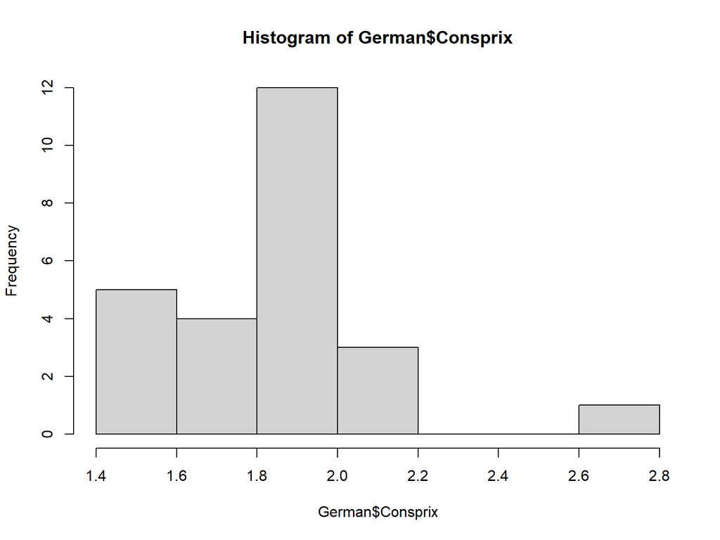

```r
hist(German$Consprix)
```

# How to visualize the distribution of each variable? (cont’d)

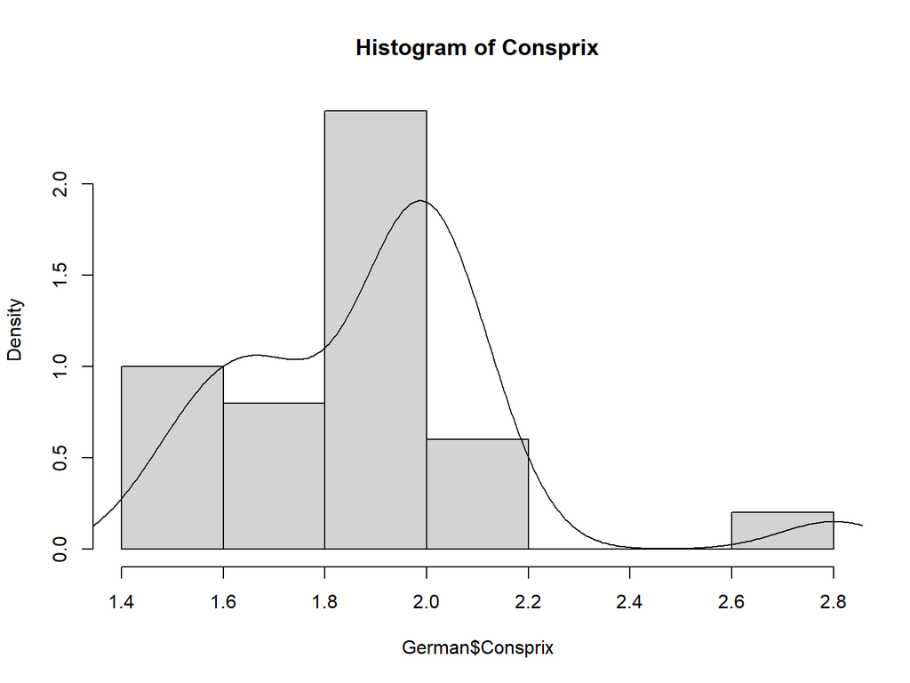

```r
hist(German$Consprix, prob=TRUE, main = sprintf('Histogram of Consprix'))   # histogram
lines(density(German$Consprix))     # smooth it - ?density for details
```

# Do we see any skewed distributions?

Note: negatively skewed vs. positively skewed

- A negative value typically indicates that the shape has longer tails on the left side, hence called skewed left or negatively skewed. The median is larger than the mean.
- A positive value typically indicates that the shape has longer tails on the right side, hence called skewed right or positively skewed. The median is smaller than the mean.

# Do we see any skewed distributions? (cont’d)

- For example: Consumer Prices (Consprix)

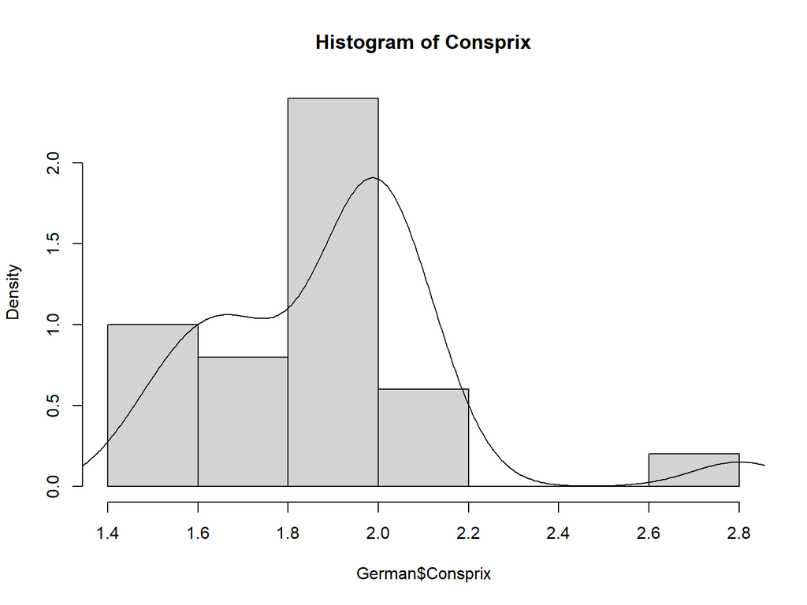

```r
hist(German$Consprix, prob=TRUE, main = sprintf('Histogram of Consprix'))   # histogram
lines(density(German$Consprix))     # smooth it - ?density for details
```

# Can we identify the correlation coefficients that are statistically significant?

- If the correlation coefficient is statistical significance, it means we have an evidence that the correlation coefficient is not exactly zero. In other words, we have an evidence that there is a linear relationship between the variables(a coefficient of 0 indicates that there is no linear relationship).
- If the correlation coefficient is NOT statistical significance, it means there is inconclusive evidence about the significance of the association between the variables.

# Can we identify the correlation coefficients that are statistically significant? (cont’d)

- The correlation between GDP and Govsurp is 0.62 and its correlation coefficient is statistical significance (with star(s)).
- The correlation between GDP and Consprix is 0.32 and its correlation coefficient is NOT statistical significance (without stars).

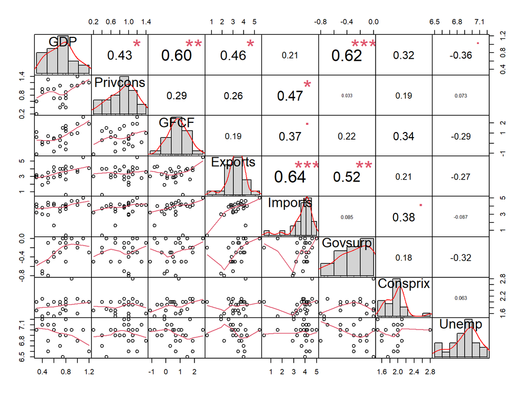

```r
library("PerformanceAnalytics")
my_data <- German[,-1]
chart.Correlation(R = my_data, histogram=TRUE, pch=19)
```

# Scatter Plot Matrices

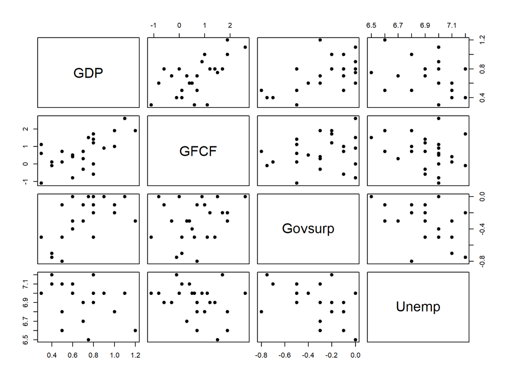

```r
pairs(x = German[,c("GDP", "GFCF", "Govsurp", "Unemp")], pch = 19)
```

```r
# Use the c() function to combine character values into a vector (or a list)
# Use indexed character vectors to select named  column(s) or row(s)
```

# Exercise

- Check correlation between GDP and GFCF

```r
cov(German$GDP, German$GFCF); sd(German$GDP); sd(German$GFCF)
```

```
## [1] 0.1345917
```

```
## [1] 0.2486966
```

```
## [1] 0.900037
```

```r
cov(German$GDP, German$GFCF) / (sd(German$GDP) * sd(German$GFCF))
```

```
## [1] 0.6012955
```

```r
# What is the meaning of the dollar  “$” in R function()?
# the $allows you extract elements by name from a named list.
```

# Revisit: Any outliers?

- An alternative approach to identify outliers is to use a box-plot and interquartile rule :1.5$\times$IQR rule.

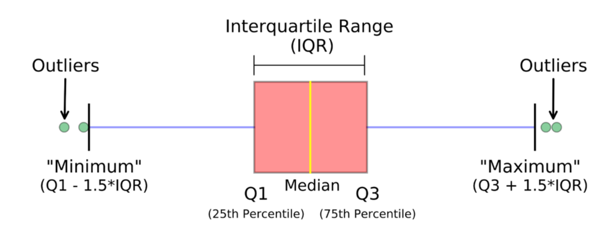

- Boxplots are a standardized way of displaying the distribution of data based on a five number summary (“minimum”, first quartile (Q1), median, third quartile (Q3), and “maximum”).

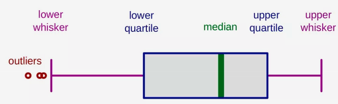

- Note: this determines how far the plot ‘whiskers’ extend out from the box. If coef is positive, the whiskers extend to the most extreme data point which is no more than coef times the length of the box away from the box.

# Revisit: Any outliers? (cont’d)

For example: Consumer Prices (Consprix)

- In R, we can use a boxplot() function

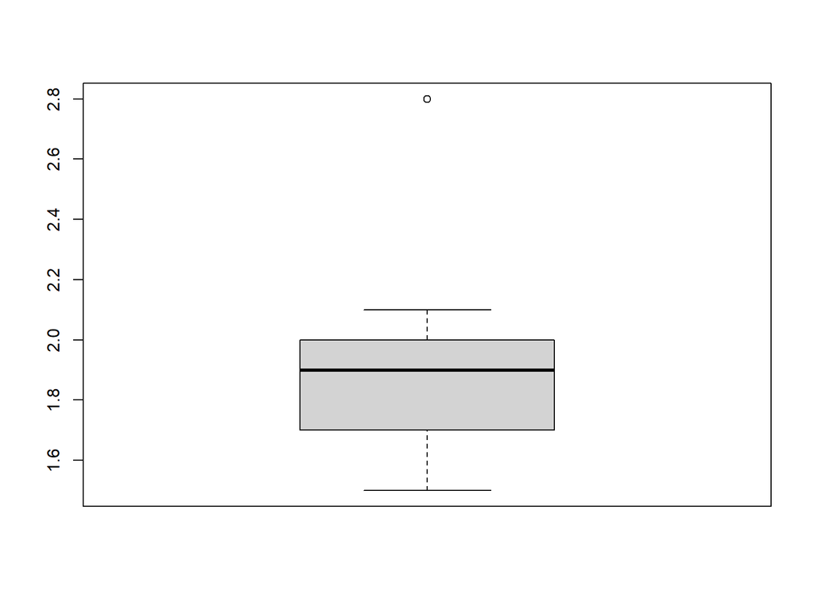

```r
boxplot(x = German$Consprix)
```

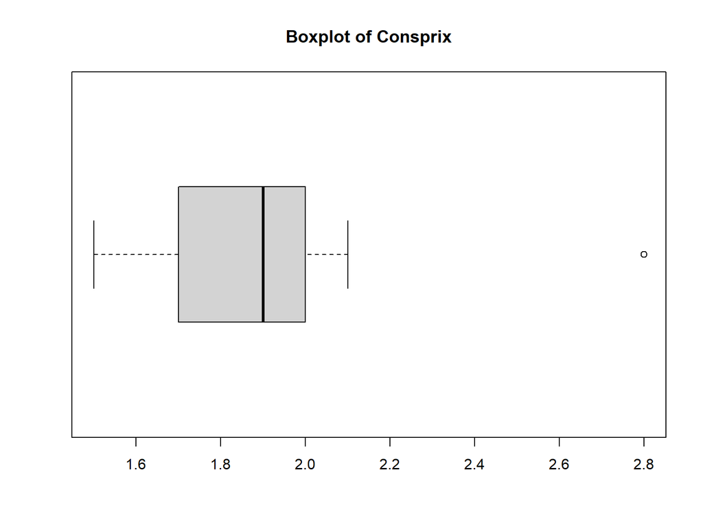

```r
boxplot(x = German$Consprix,horizontal = TRUE, main = sprintf('Boxplot of Consprix'))
```

# Revisit: Any outliers? (cont’d)

- In R, we can use a boxplot() function

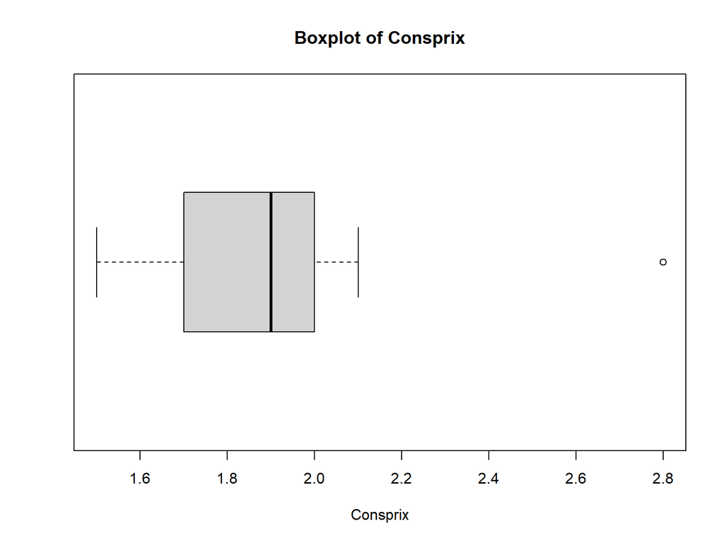

```r
boxplot(x = German$Consprix,
        horizontal = TRUE,
        main = sprintf('Boxplot of Consprix'),
        xlab = 'Consprix')
```

# Revisit: Any outliers? (cont’d)

```r
boxplot.stats(German$Consprix, coef = 1.5, do.conf=TRUE, do.out=TRUE)
```

```
## $stats
## [1] 1.5 1.7 1.9 2.0 2.1
##
## $n
## [1] 25
##
## $conf
## [1] 1.8052 1.9948
##
## $out
## [1] 2.8
```

```r
boxplot.stats(German$Consprix, coef = 1.5, do.conf=TRUE, do.out=TRUE)$out
```

```
## [1] 2.8
```

```r
which(German$Consprix%in%c(2.8))
```

```
## [1] 5
```

```r
German$Institutions[5]
```

```
## [1] "DIW"
```